# Loans by Category: Borrowers and Characteristics

## by Chris Silvia

## Dataset Overview

This data covers 113,937 loans from Prosper, with loan information going up until 2014. There are many variables provided for each loan, including a lot of information about the borrowers and about the loans.

## Investigation Overview

Each loan has a listing category associated with it, which states the purpose of the loan. Some examples include debt consolidation, home improvement, weddings, vacations, or student usage. The question I wanted to answer was how the qualities of the borrowers and the loans themselves differed based on these listing categories.

## Listing Categories by Frequency

Below displays all of the types of loan categories included in the dataset, and how frequent they are. Debt consolidation overwhelms all other loan types. For the specific categories after that, home improvement and business are definitely the most common.

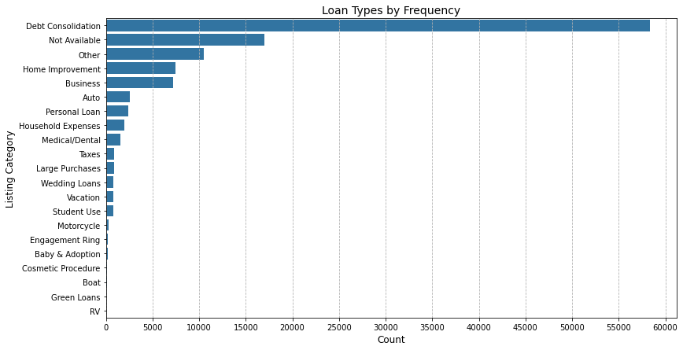

## Average Original Loan Amounts Based on Category

This chart displays the average amount of the loans in each category when it was first funded. Interestingly baby and adoption loans seem to be the second largest after debt consolidation, but the long grey line indicates there's a lot of variation in that data.

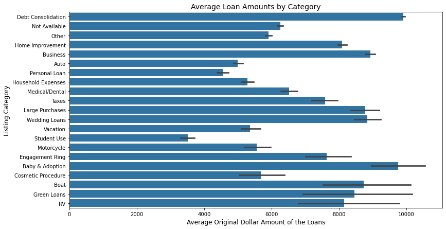

## Loan Categories by Income Range

Next are the various loan types displayed by frequency for the various income ranges in the dataset. I removed debt consolidation, not available, and other type loans from this visualization, since they don't provide much information and drown out the rest of the categories.

Noticeably, business loans are the most frequent for every income group up until \$50k, at which point home improvement loans become the most frequent.

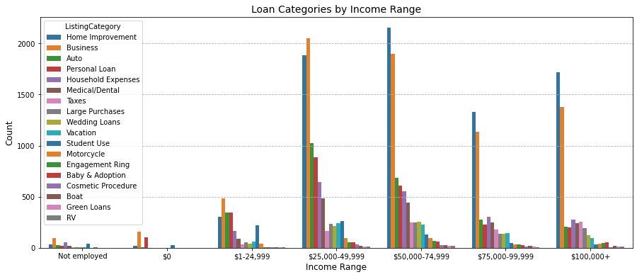

## The Loan Borrowers

This grid of scatter plots combines the borrowers' stated monthly income on the x axis and their approximate credit score on the y axis. I actually had to cap the stated monthly income to a maximum of \$10k, as the outliers further than that got so extreme.

The coloration displays the borrower's debt to income ratio; the darkest colors are individuals who have an overall debt many times their annual income, whereas the lighter color points do not have much debt when compared to their income.

Overall, as you move to the less frequent categories, the borrowers have less relative debt to their income, and the distribution of their income isn't clustered on the lower end of the spectrum.

[figure not shown]

## The Loans

These next scatter plots detail various information about the loans. The x axis is the original amount of the loan when it was funded, and the y axis is the annual percentage rate of the loan. You can see that loans of greater amounts generally have lower APRs. The underlying blue dots are loans that were not charged off, and the overlaid orange dots indicate loans that were charged off. In other words, after many missed payments, they gave up trying to collect on the loan.

It's possible to see that the APR drops at certain even loan amounts instead of steadily decreasing. Charged off loans are also much more common among lower loan amounts, which could be the result of a variety of factors.

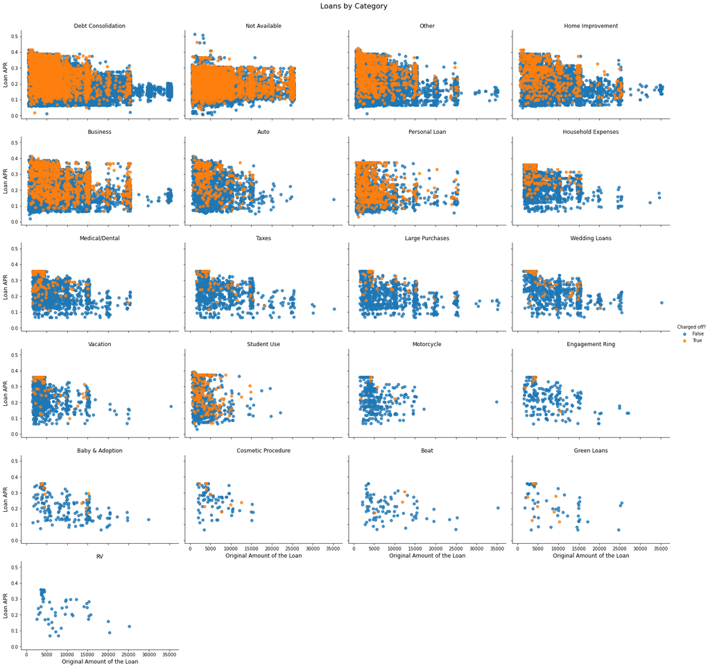

## Conclusion

I think the most drastic difference I see between the categories are between what I would call "need" categories, such as handling debt, a business, a home, a car, taxes, or for student use, and "want" categories, which are purchases that people don't necessarily need but desire, such as an engagement ring, cosmetic procedure, a boat, or a vacation.

The pie chart below puts together the proportion of overall debt in the dataset each category composes by total, using the original loan amounts. It would be very interesting if it were possible to see what the original forms those debt were, but I think it makes a concerning statement about the state of debt overall that the majority of it here is simply people attempting to make their existing debt more manageable.

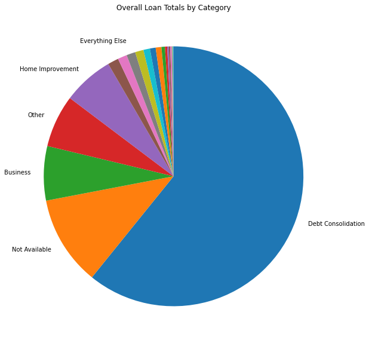